# Unit-8b: Data Exploration and Modelling, Part I

## Agenda

We will follow the example from the UVA statslab, link:

https://uvastatlab.github.io/phdplus/linearmodel.html

1. Load libraries, read in data
2. Before you model, explore
3. Linear model estimation, inference
4. Model Specification, factors, interactions
5. Model evaluation, F-tests

## Setup

Some packages you will need

```r
install.packages("tidyverse")
library(tidyverse)
library(GGally)  # additional plotting functions
library(broom)   # tidy up model output
```

## Exploration dataset: homes

The data is about homes in Albemarle County, VA

[figure not shown]

## Get data from github

```r
github_url <-
"https://github.com/uvastatlab/phdplus/raw/master/data/albemarle_homes.rds"
homes <- readRDS(url(github_url))
str(homes)
```

Take some time to look at and inspect the data

`str(homes)` gives values and types of each variable

`View(homes)` Take some time to view and look at the data

There are 32,746 homes, (rows) in the database

Each row has 26 variables describing features

| tmp | yearbuilt | yearremodeled | usecode | condition | finsqft | cooling | fp_num | bedroom | fullbath | halfbath | totalrooms | city | zip | lotsize | landvalue | improvementsvalue | totalvalue | lastsaleprice | lastsaledate | age | med_age | fp | landuse | insub | remodel |
| --- | --- | --- | --- | --- | --- | --- | --- | --- | --- | --- | --- | --- | --- | --- | --- | --- | --- | --- | --- | --- | --- | --- | --- | --- | --- |
| 006000000011B0 | 2006 | 0 | Single Family | Average | 1922 | Central Air | 1 | 3 | 3 | 0 | 10 | CROZET | 22932 | 5.000 | 109800 | 300100 | 409900 | 0 | 2009-08-05 | 10 | 17 | 1 | 0 | 0 | 0 |
| 00600000003800 | 2003 | 0 | Single Family | Average | 1848 | Central Air | 0 | 3 | 2 | 0 | 7 | CROZET | 22932 | 61.189 | 444100 | 79000 | 523100 | 0 | 1991-05-20 | 13 | 17 | 0 | 0 | 0 | 0 |
| 007000000018B0 | 1974 | 0 | Single Family | Average | 1368 | No Central Air | 0 | 3 | 1 | 0 | 5 | OTHER | 22940 | 5.390 | 100400 | 128400 | 228800 | 0 | 1989-02-23 | 42 | 33 | 0 | 0 | 0 | 0 |
| 007000000042A0 | 1954 | 0 | Single Family | Average | 1092 | No Central Air | 0 | 4 | 1 | 0 | 6 | OTHER | 22940 | 5.800 | 100700 | 77200 | 177900 | 0 | 2001-10-05 | 62 | 33 | 0 | 0 | 0 | 0 |
| 007000000042B0 | 1987 | 0 | Single Family | Average | 1344 | Central Air | 0 | 3 | 2 | 0 | 5 | OTHER | 22940 | 2.344 | 66500 | 165900 | 232400 | 0 | 2009-05-20 | 29 | 33 | 0 | 0 | 0 | 0 |
| 00700000004600 | 1920 | 1987 | Single Family | Fair | 2131 | No Central Air | 0 | 5 | 2 | 0 | 8 | OTHER | 22940 | 35.100 | 340300 | 85000 | 425300 | 0 | 2011-02-09 | 96 | 33 | 0 | 1 | 0 | 1 |

## Real estate terms

- The **“land value”** is the value of the land – i.e., the physical ground and dirt that makes up the land.
- The **“improvements value”** is the value of improvements – an "improvement’ usually means a home/house/structure etc

So, if you own a house for example, the land that the house sits on is the “land value” and the house itself is the “improvement.”

\[\textrm{total value } = \textrm{land value } + \textrm{improvements value }\]

**SIDENOTE**: *Assessment value* is a somewhat arbitrary figure that your local property tax collector determines and then has a formula to calculate your annual real estate property taxes. The assessment value is usually significantly lower than the TOTAL VALUE but this varies from state to state.

## Plot improvemnts value vs sqft

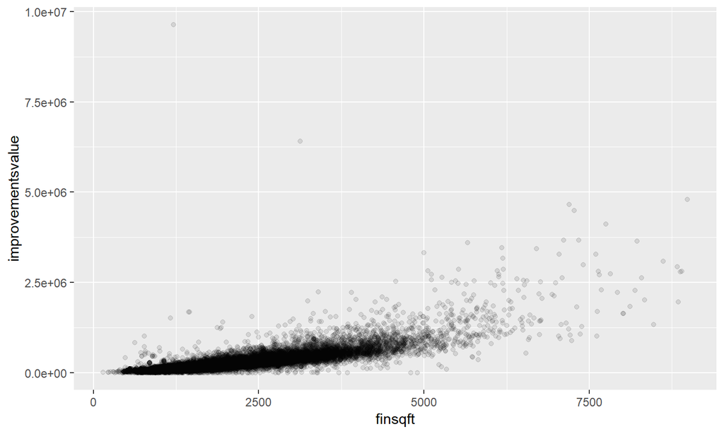

```r
plt <- ggplot(homes, aes(x = finsqft, y = improvementsvalue))
plt + geom_point(alpha = 1/10)
```

## Binning data by sq ft

Below, we create some custom bins and add a column to the table indicating what square foot bin each home belongs to

```r
sqft_break <- c(0, 250, 500, 750, 1250, 1500, 1750, 2000, 2250,
                2500, 2750, 3000, 3250, 3500, 3750, 4000, 4250,
                4500, 4750, 5000, 5250, 5550, 5750, 6000, 6250,
                6500, 6750, 7000, 7250, 7500, 7750, 8000, Inf)
homes_tmp <- homes %>%
  mutate(sqft_bins = cut(finsqft, breaks = sqft_break)) %>%  # cut
  group_by(sqft_bins) %>%
  mutate(bin_meany = mean(improvementsvalue),    # mean in bin
         bin_medx = max(finsqft)) %>%            #
  ungroup()
```

Below is the frequency table for square footage of homes

Examine the frequencies in each bin

```r
table(round(homes_tmp$bin_medx, 0))
```

| bin_right_edge | frequency |
| --- | --- |
| 231 | 3 |
| 500 | 45 |
| 750 | 563 |
| 1250 | 7188 |
| 1500 | 5035 |
| 1750 | 4064 |
| 2000 | 3191 |
| 2250 | 2783 |
| 2500 | 2457 |
| 2750 | 1890 |
| 3000 | 1550 |
| 3250 | 1077 |
| 3500 | 807 |
| 3750 | 555 |
| 4000 | 366 |
| 4250 | 325 |
| 4496 | 228 |
| 4747 | 172 |
| 5000 | 97 |
| 5250 | 82 |
| 5547 | 76 |
| 5747 | 45 |
| 5991 | 36 |
| 6226 | 32 |
| 6498 | 17 |
| 6747 | 15 |
| 6988 | 7 |
| 7237 | 11 |
| 7413 | 6 |
| 7680 | 6 |
| 7928 | 3 |
| 8982 | 14 |

## Plot with bins

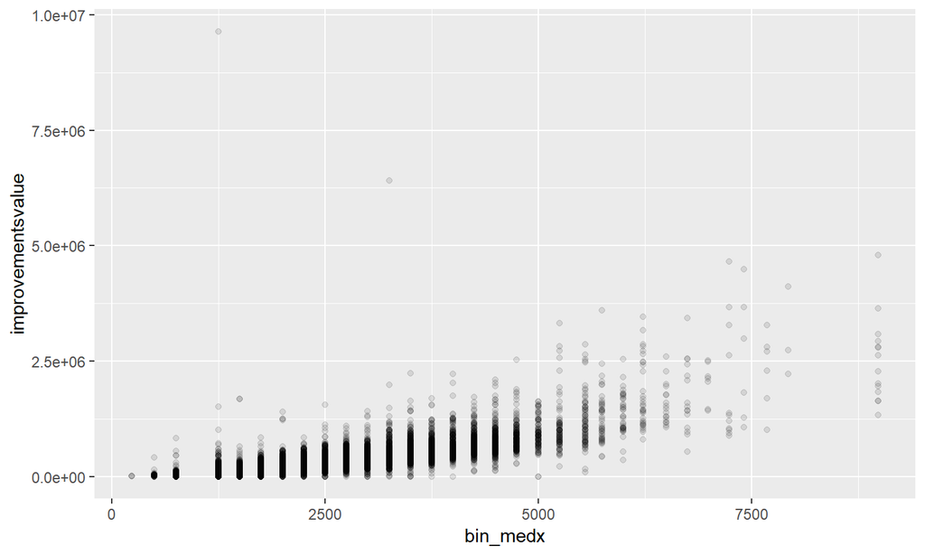

```r
p <- ggplot(homes_tmp, aes(x = bin_medx, y = improvementsvalue))
p + geom_point(alpha = 1/10) # all pts have the SAME transparency!
```

## plot with conditional means

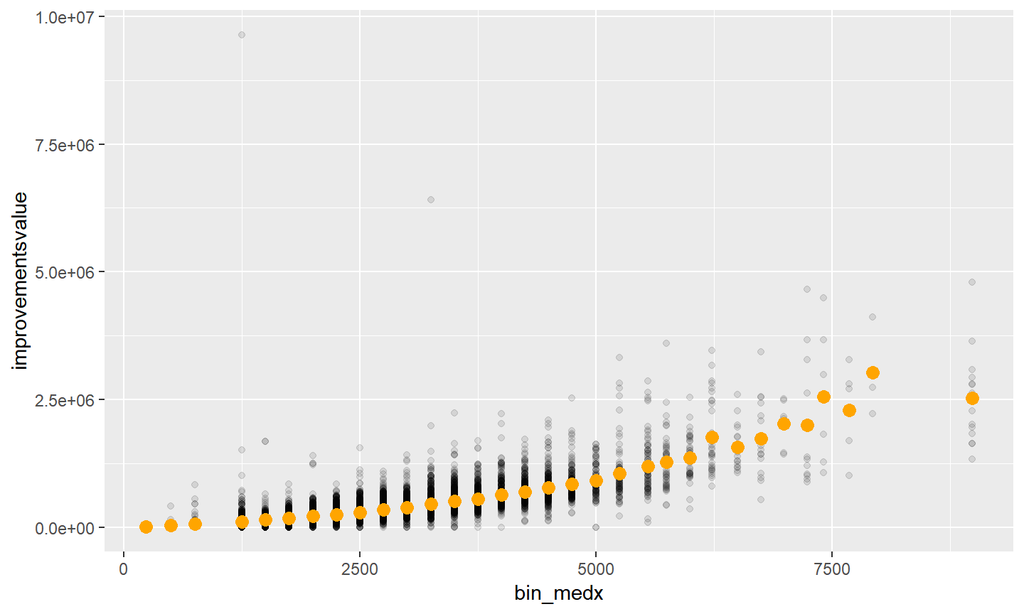

```r
p + geom_point(alpha = 1/10) +  # note I am adding to previous slide's plot!
  geom_point(aes(x=bin_medx, y=bin_meany), color = "orange", size = 3)
```

## plot with line connecting means

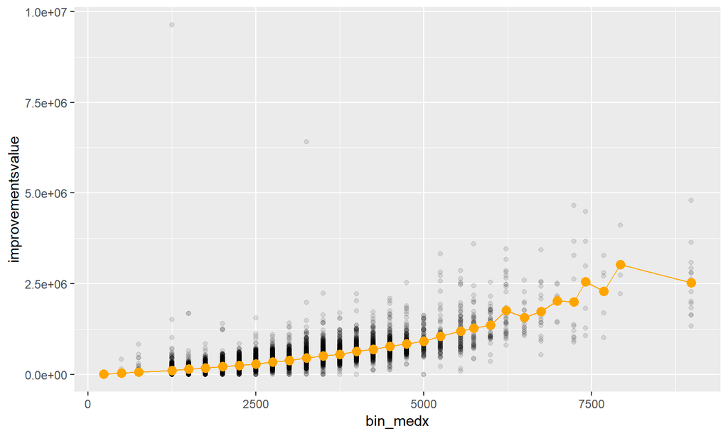

```r
p + geom_point(alpha = 1/10) +
  geom_point(aes(x=bin_medx,y=bin_meany),color="orange",size=3) +
  geom_line(aes(x=bin_medx, y=bin_meany), color = "orange")
```

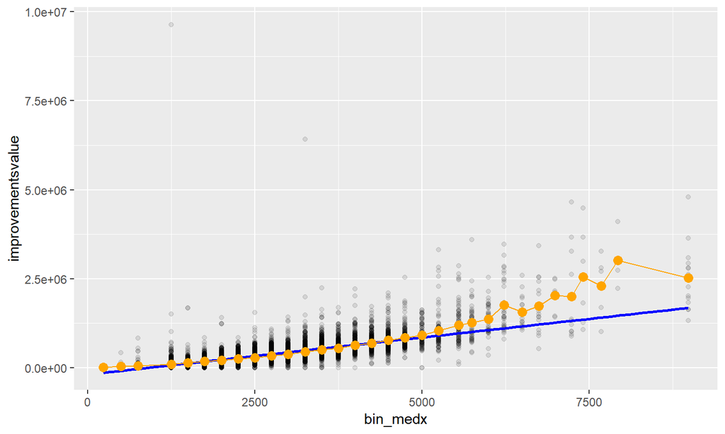

```r
p + geom_point(alpha = 1/10) +
  geom_smooth(method = "lm", se = FALSE, color = "blue") + # LR
  geom_point(aes(x=bin_medx,y=bin_meany),color="orange",size = 3) +
  geom_line(aes(x = bin_medx, y = bin_meany), color = "orange")
```

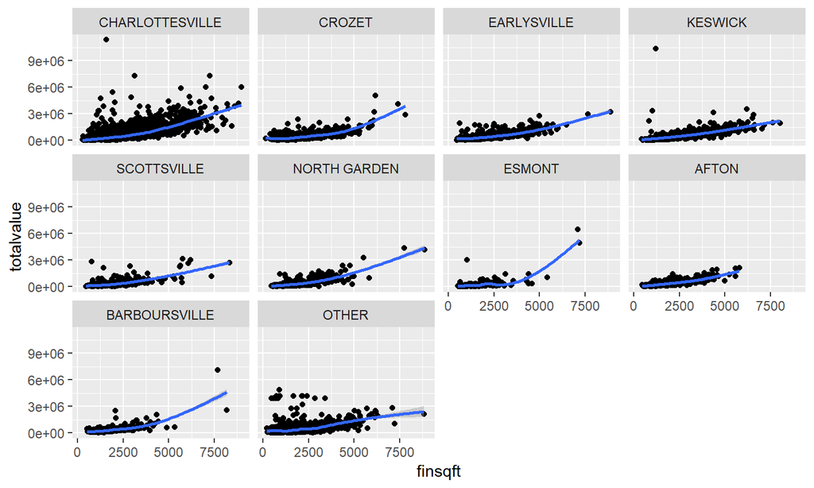

```r
ggplot(homes,
       aes(y = totalvalue, x = finsqft)) +
  geom_point() +
  geom_smooth() +
  facet_wrap(~ city)  # facet by city
```

## YOUR TURN:

- create a graph of the relatonship between totalvalue and another numeric variable of your choice, faceting by city

## Running regressions

```r
fit = lm(improvementsvalue ~ bin_medx, data = homes_tmp)
homes_tmp$predicted <- predict(fit)
homes_tmp$residuals <- residuals(fit)
# sample 500 homes
homes_tmp_samp <- homes_tmp %>% sample_n(size = 500)
# notice sample_n(df,size) return a dataframe!
```

plot it

```r
ggplot(homes_tmp_samp, aes(x = bin_medx, y = improvementsvalue)) +
  geom_point(aes(color = residuals)) +
  geom_line(aes(y = predicted)) +
  geom_segment(aes(xend = bin_medx, yend = predicted)) +
  scale_color_gradient2(low = "blue", mid = "white", high = "red") +
  guides(color = FALSE)
```

(resulting plot is on next slide)

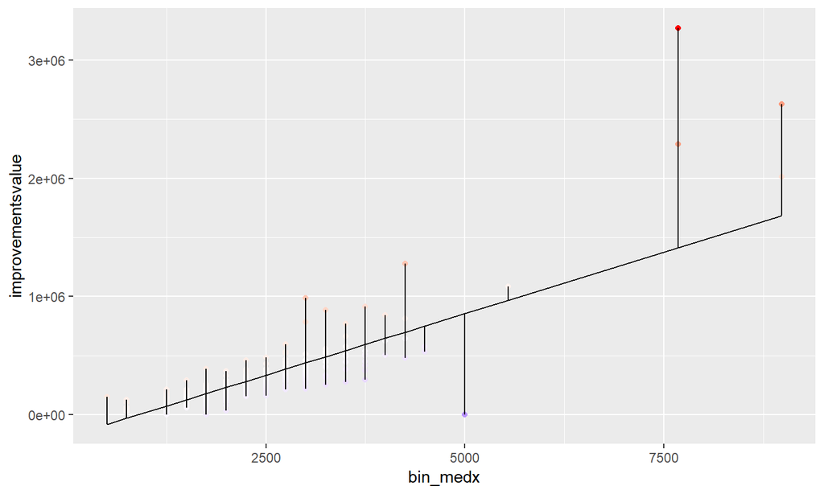

There are multiple data points in each bin

## Regression results

```r
fit
```

```
##
## Call:
## lm(formula = improvementsvalue ~ bin_medx, data = homes_tmp)
##
## Coefficients:
## (Intercept)     bin_medx
##   -185678.6        208.1
```

This tells us that

\[\textrm{improvementsvalue} = -185678.6 + 208\times\textrm{Squarefeet}\]

the intercept is essentially meaningless (why?)

## Multiple regression

The basic method in R is `lm(Y ~ X1 + X2, data = mydata)`

```r
multi_fit <- lm(improvementsvalue ~ finsqft + age + lotsize,
                data=homes)
```

To get the output run `summary(multi_fit)`

(results are on next page)

```
##
## Call:
## lm(formula = improvementsvalue ~ finsqft + age + lotsize, data = homes)
##
## Residuals:
##     Min      1Q  Median      3Q     Max
## -983506  -52254     -14   41003 8832959
##
## Coefficients:
##               Estimate Std. Error t value Pr(>|t|)
## (Intercept) -132087.07    2174.03  -60.76   <2e-16 ***
## finsqft         199.53       0.86  232.00   <2e-16 ***
## age            -374.91      29.77  -12.59   <2e-16 ***
## lotsize        1169.92      36.60   31.96   <2e-16 ***
## ---
## Signif. codes:  0 '***' 0.001 '**' 0.01 '*' 0.05 '.' 0.1 ' ' 1
##
## Residual standard error: 142600 on 32741 degrees of freedom
##   (1 observation deleted due to missingness)
## Multiple R-squared:  0.6453, Adjusted R-squared:  0.6452
## F-statistic: 1.985e+04 on 3 and 32741 DF,  p-value: < 2.2e-16
```

- **Call**: The model formula, useful if result is saved for later
- **Residuals**: A quick check of the distribution of residuals. Ideally, median is near 0, max and min, and 1Q and 3Q, are approximately equivalent.
- **Coefficients**:
- **Estimate**: \(\hat{\beta}\)
- **Std. error**: standard error of \(\hat{\beta}\)
- **t value**: test statistic for \(H_0: \hat{\beta}=0\) calculated by \(\frac{estimate}{SE}\)
- **\(Pr(>|t|)\)**: \(p\) value of hypothesis test (two-sided)
- **Signif. codes**: indicate statistical significance
- **Residual standard error**: \(\hat{\sigma}\)
- **degrees of freedom**: # of obs - # of estimated parameters
- **Multiple R-squared**: measure of model fit (0,1)
- **Adjusted R-squared**: measure of model fit adjusted for number of parameters (0,1)
- **F-statistic**: test statistic for hypothesis that all coefficients (other than intercept) simultaneously equal zero
- **p-value**: \(p\)-value for F-statistics

## Specifying models

`response variable ~ explanatory variables`

The tilde (~) is read as “is modelled as a function of” or “regressed on.” Additional model symbols are include:

+ inclusion of variable

- exclusion of variable (not subtraction)

∗ include variables and their interactions

: interact variables

∧ interaction of variables to specified degree (**not an exponent**)

To override a model symbol, use the I() function.

`y ~ x1 + x2 + x3` (multiple regression)

`y ~ .` (regress y on all variables in data set)

`y ~ x1 + x2 - 1` (exclude intercept)

`y ~ x1 + x2 + x1:x2` (interact x1 and x2)

`y ~ x1 * x2` (same as above)

`y ~ x1 + x2 + x3 + x1:x2 + x1:x3 + x2:x3 + x1:x2:x3` (all two and three-way interactions)

`y ~ x1 * x2 * x3` (same as above)

`y ~ (x1 + x2 + x3)ˆ2` (all 2-way interactions)

`y ~ x1 + I(x1ˆ2) + x3` (polynomial regression)

`y ~ poly(x1, 2, raw = TRUE) + x3` (polynomial regresion)

For inclusion in a model, R requires categorical predictors – like city or condition in the Albemarle housing data – to be encoded as factors.

By default, coefficients for factors are modeled using treatment contrasts – one level is treated as the baseline and the other levels have coefficients that express differences from that baseline. e.g. the effect is like changing the intercept for each city.

| Var1 | Freq |
| --- | --- |
| CHARLOTTESVILLE | 21113 |
| CROZET | 3018 |
| EARLYSVILLE | 1920 |
| KESWICK | 1619 |
| SCOTTSVILLE | 1077 |
| NORTH GARDEN | 620 |
| ESMONT | 538 |
| AFTON | 519 |
| BARBOURSVILLE | 422 |
| OTHER | 1900 |

```r
multi_factor_fit <- lm(improvementsvalue ~ city + finsqft + age + lotsize,
                  data = homes)
summary(multi_factor_fit)$coefficients
```

```
##                       Estimate   Std. Error    t value      Pr(>|t|)
## (Intercept)       -125953.0467 2218.0860385 -56.784563  0.000000e+00
## cityCROZET         -23671.9814 2768.5983234  -8.550168  1.281644e-17
## cityEARLYSVILLE    -24414.1696 3404.3395738  -7.171485  7.576004e-13
## cityKESWICK        -21780.2455 3713.8791314  -5.864554  4.546610e-09
## citySCOTTSVILLE    -24388.7281 4476.6092182  -5.448036  5.129562e-08
## cityNORTH GARDEN   -21726.3610 5820.0449291  -3.733023  1.895156e-04
## cityESMONT         -30024.8947 6244.9599662  -4.807860  1.532311e-06
## cityAFTON          -20993.8441 6335.6698785  -3.313595  9.220471e-04
## cityBARBOURSVILLE  -35097.1347 7000.5571540  -5.013477  5.373380e-07
## cityOTHER          -26814.8719 3446.2399799  -7.780907  7.411631e-15
## finsqft               200.0027    0.8751986 228.522615  0.000000e+00
## age                  -332.5918   30.0283137 -11.075939  1.844363e-28
## lotsize              1234.6039   36.8893714  33.467741 1.693763e-241
```

## Diagnostic:check residuals

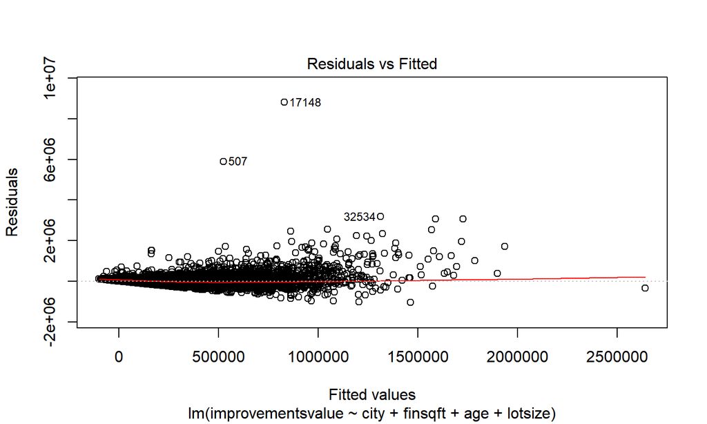

```r
plot(multi_factor_fit, which = 1)
```

## Evaluating model specification, fit

What should be included in a model, and in what form, are questions of model specification (aka feature selection).

To test whether inclusion of a subset of variables substantially improves a model, we can use a partial F-test to compare models with and without this subset of variables.

```r
lm_full <- lm(improvementsvalue ~ city*finsqft + age + lotsize,
                  data = homes)
lm_red <- lm(improvementsvalue ~ city + finsqft + age + lotsize,
                  data = homes)
anova(lm_red, lm_full)
```

```
## Analysis of Variance Table
##
## Model 1: improvementsvalue ~ city + finsqft + age + lotsize
## Model 2: improvementsvalue ~ city * finsqft + age + lotsize
##   Res.Df        RSS Df  Sum of Sq      F    Pr(>F)
## 1  32732 6.6142e+14
## 2  32723 6.5700e+14  9 4.4236e+12 24.481 < 2.2e-16 ***
## ---
## Signif. codes:  0 '***' 0.001 '**' 0.01 '*' 0.05 '.' 0.1 ' ' 1
```

the null hypothesis is that the models are the same.

clearly, the full model better fits the data

## YOUR TURN:

- estimate your own model of totalvalue –
- add at least one predictor, save it as a new model object,
- and summarize the model;
- are the newly added variables significantly related?
- do the effects of the initially included variables change?
- try to plot conditionals with confidence and prediction intervals

## Additional Exercises Unit 8b

1. For all the homes in Albemarle dataset, calculate the average last sale price, for homes where the last sale price is known.
2. Compare the average sale price to the average total value of all homes
3. Repeat the steps in exercise 1. and 2. but this time, restrict the data to only homes that were sold in year 2000 or later